# Assessment 3 of Mihiravi

Mihiravi

21/05/2021

##Part 1

#Question 1

```r
download.file("https://raw.githubusercontent.com/markziemann/SLE712_files/master/assessment_task3/bioinfo_asst3_part1_files/gene_expression.tsv",
              destfile = "gene_expression.tsv")
gene_expression <- read.table("gene_expression.tsv",
                              header = TRUE,
                              row.names = 1)
str(gene_expression)
```

```
## 'data.frame':    58302 obs. of  2 variables:
##  $ SRR5150592: int  1 0 0 0 0 0 0 0 0 0 ...
##  $ SRR5150593: int  0 1 0 0 0 0 0 0 0 0 ...
```

```r
head(gene_expression)
```

```
##                 SRR5150592 SRR5150593
## ENSG00000223972          1          0
## ENSG00000227232          0          1
## ENSG00000278267          0          0
## ENSG00000243485          0          0
## ENSG00000284332          0          0
## ENSG00000237613          0          0
```

```r
# get rows 1-6 of all columns to appear
gene_expression[1:6,]
```

```
##                 SRR5150592 SRR5150593
## ENSG00000223972          1          0
## ENSG00000227232          0          1
## ENSG00000278267          0          0
## ENSG00000243485          0          0
## ENSG00000284332          0          0
## ENSG00000237613          0          0
```

#Question 2

#new column for analysing row mean values

```r
# to find the row means
head(gene_expression)
```

```
##                 SRR5150592 SRR5150593
## ENSG00000223972          1          0
## ENSG00000227232          0          1
## ENSG00000278267          0          0
## ENSG00000243485          0          0
## ENSG00000284332          0          0
## ENSG00000237613          0          0
```

```r
row_means <- rowMeans(gene_expression)
head(row_means)
```

```
## ENSG00000223972 ENSG00000227232 ENSG00000278267 ENSG00000243485 ENSG00000284332
##             0.5             0.5             0.0             0.0             0.0
## ENSG00000237613
##             0.0
```

```r
gene_expression$mean <- c(row_means)
# to show only 6 rows in the table
gene_expression[1:6,]
```

```
##                 SRR5150592 SRR5150593 mean
## ENSG00000223972          1          0  0.5
## ENSG00000227232          0          1  0.5
## ENSG00000278267          0          0  0.0
## ENSG00000243485          0          0  0.0
## ENSG00000284332          0          0  0.0
## ENSG00000237613          0          0  0.0
```

#Question 3

#10 genes with the highest mean expression

```r
#bring the highest values to the top of data set by using reverse sorting
reverse_sorted<- gene_expression[order(-gene_expression$mean),]
#to get the 10 highest mean values
reverse_sorted[1:10, "mean"]
```

```
##  [1] 259102.0 154602.0 125372.5  95769.5  84852.0  82303.0  79079.5  77319.0
##  [9]  76608.0  70234.5
```

#Question 4

#number of genes with a mean <10

```r
number_genes <- sum(gene_expression$mean <10)
number_genes
```

```
## [1] 43124
```

#Question 5

#histogram plot of the mean values in png format

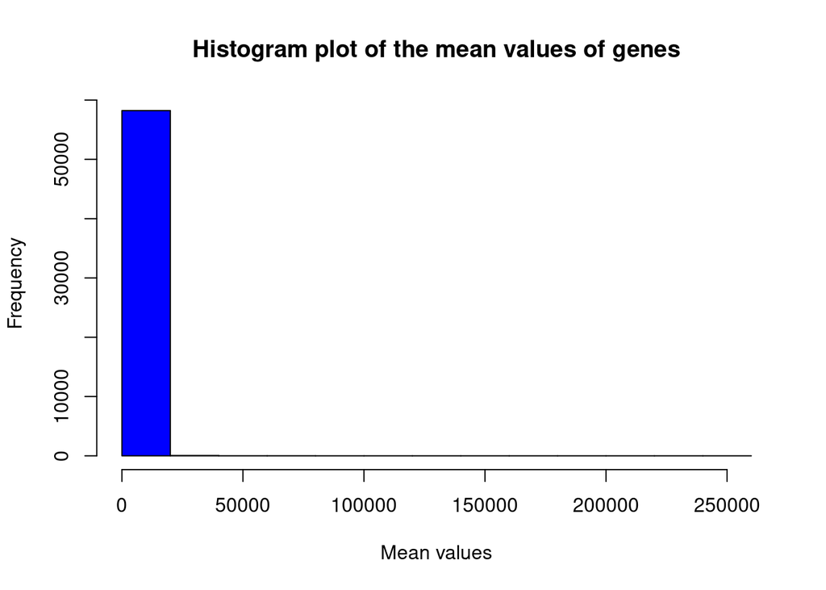

```r
hist (gene_expression$mean,
     main = "Histogram plot of the mean values of genes",
     xlab = "Mean values",
     col = "blue")
```

```r
# to save as a png format
png(file="Histogram plot of the mean values of genes")
```

#Question 6

#downloading the growth_data.csv file

```r
download.file("https://raw.githubusercontent.com/markziemann/SLE712_files/master/assessment_task3/bioinfo_asst3_part1_files/growth_data.csv", destfile = "growth_data.csv")
Growth_data <- read.csv("growth_data.csv", header = TRUE, stringsAsFactors = FALSE)
head(Growth_data)
```

```
##        Site TreeID Circumf_2004_cm Circumf_2009_cm Circumf_2014_cm
## 1 northeast   A003             5.2            10.1            19.9
## 2 northeast   A005             4.9             9.6            18.9
## 3 northeast   A007             3.7             7.3            14.3
## 4 northeast   A008             3.8             6.5            10.9
## 5 northeast   A011             3.8             6.4            10.9
## 6 northeast   A012             5.9            10.0            16.8
##   Circumf_2019_cm
## 1            38.9
## 2            37.0
## 3            28.1
## 4            18.5
## 5            18.4
## 6            28.4
```

```r
colnames(Growth_data)
```

```
## [1] "Site"            "TreeID"          "Circumf_2004_cm" "Circumf_2009_cm"
## [5] "Circumf_2014_cm" "Circumf_2019_cm"
```

#Question 7

#mean and standard deviation of tree circumference at the start and end of the study at both sites

```r
# for the northeast data set for 2004
NE <- subset(Growth_data, Site== "northeast")
head(NE)
```

```
##        Site TreeID Circumf_2004_cm Circumf_2009_cm Circumf_2014_cm
## 1 northeast   A003             5.2            10.1            19.9
## 2 northeast   A005             4.9             9.6            18.9
## 3 northeast   A007             3.7             7.3            14.3
## 4 northeast   A008             3.8             6.5            10.9
## 5 northeast   A011             3.8             6.4            10.9
## 6 northeast   A012             5.9            10.0            16.8
##   Circumf_2019_cm
## 1            38.9
## 2            37.0
## 3            28.1
## 4            18.5
## 5            18.4
## 6            28.4
```

```r
str(NE)
```

```
## 'data.frame':    50 obs. of  6 variables:
##  $ Site           : chr  "northeast" "northeast" "northeast" "northeast" ...
##  $ TreeID         : chr  "A003" "A005" "A007" "A008" ...
##  $ Circumf_2004_cm: num  5.2 4.9 3.7 3.8 3.8 5.9 4.4 5.3 7.1 3.8 ...
##  $ Circumf_2009_cm: num  10.1 9.6 7.3 6.5 6.4 10 9.9 9 12 7.4 ...
##  $ Circumf_2014_cm: num  19.9 18.9 14.3 10.9 10.9 16.8 22.2 15.2 20.2 14.5 ...
##  $ Circumf_2019_cm: num  38.9 37 28.1 18.5 18.4 28.4 50 25.8 34.2 28.4 ...
```

```r
# to find the mean of 2004 for NE
mean_2004_NE <- mean(NE$Circumf_2004_cm)
mean_2004_NE
```

```
## [1] 5.078
```

```r
# to find the SD of 2004 for NE
SD_2004_NE <- sd(NE$Circumf_2004_cm)
SD_2004_NE
```

```
## [1] 1.059127
```

```r
## for the southwest data set for 2004
SW <- subset(Growth_data, Site=="southwest")
head(SW)
```

```
##         Site TreeID Circumf_2004_cm Circumf_2009_cm Circumf_2014_cm
## 51 southwest   A001             5.3            13.5            34.6
## 52 southwest   A002             5.2            10.1            19.8
## 53 southwest   A004             6.2            15.9            40.6
## 54 southwest   A006             5.1            11.5            25.9
## 55 southwest   A009             3.6             9.1            23.4
## 56 southwest   A010             6.6            14.9            33.6
##    Circumf_2019_cm
## 51            88.7
## 52            38.8
## 53           103.9
## 54            58.3
## 55            59.8
## 56            75.5
```

```r
str(SW)
```

```
## 'data.frame':    50 obs. of  6 variables:
##  $ Site           : chr  "southwest" "southwest" "southwest" "southwest" ...
##  $ TreeID         : chr  "A001" "A002" "A004" "A006" ...
##  $ Circumf_2004_cm: num  5.3 5.2 6.2 5.1 3.6 6.6 6.6 5.1 4.1 4.4 ...
##  $ Circumf_2009_cm: num  13.5 10.1 15.9 11.5 9.1 14.9 16.9 12.9 10.6 8.7 ...
##  $ Circumf_2014_cm: num  34.6 19.8 40.6 25.9 23.4 33.6 43.2 33.2 27.1 17 ...
##  $ Circumf_2019_cm: num  88.7 38.8 103.9 58.3 59.8 ...
```

```r
# to find the mean of 2004 for SW
mean_2004_SW <- mean(SW$Circumf_2004_cm)
mean_2004_SW
```

```
## [1] 5.076
```

```r
# to find the SD of 2004 for SW
SD_2004_SW <- sd(SW$Circumf_2004_cm)
SD_2004_SW
```

```
## [1] 1.060527
```

```r
##For year 2019

# for the northeast data set
# to find the mean of 2004 for NE
mean_2019_NE <- mean(NE$Circumf_2019_cm)
mean_2019_NE
```

```
## [1] 40.052
```

```r
# to find the SD of 2004 for NE
SD_2019_NE <- sd(NE$Circumf_2019_cm)
SD_2019_NE
```

```
## [1] 16.90443
```

```r
# # for the southwest data set for 2019
# to find the mean of 2019 for SW
mean_2019_SW <- mean(SW$Circumf_2019_cm)
mean_2019_SW
```

```
## [1] 59.772
```

```r
#to find the SD of 2019 for SW
SD_2019_SW <- sd(SW$Circumf_2019_cm)
SD_2019_SW
```

```
## [1] 22.57784
```

#Question 8

#box plot of tree circumference at the start and end of the study at both sites

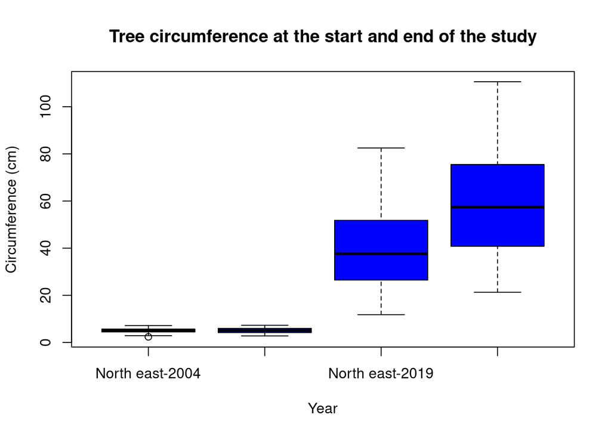

```r
boxplot(NE$Circumf_2004_cm, SW$Circumf_2004_cm, NE$Circumf_2019_cm, SW$Circumf_2019_cm,
    names = c("North east-2004","South west-2004","North east-2019","South west-2019"),
    ylab=("Circumference (cm)"),
    xlab= ("Year"),
    col = "blue",
    main= "Tree circumference at the start and end of the study")
```

#Question 9

#mean growth over the past 10 years at each site

```r
#for northeast site
growth_2009_NE <- mean(NE$Circumf_2009_cm)
head(growth_2009_NE)
```

```
## [1] 9.976
```

```r
growth_2019_NE <- mean(NE$Circumf_2019_cm)
head(growth_2019_NE)
```

```
## [1] 40.052
```

```r
#mean growth in northeast site
treegrowth_NE <- (growth_2019_NE -growth_2009_NE )
treegrowth_NE
```

```
## [1] 30.076
```

```r
#for southeast site

growth_2019_SW <- mean(SW$Circumf_2019_cm)
head(growth_2019_SW)
```

```
## [1] 59.772
```

```r
growth_2009_SW <- mean(SW$Circumf_2009_cm)
head(growth_2009_SW)
```

```
## [1] 11.418
```

```r
#mean growth in southeast site
treegrowth_SW <- (growth_2019_SW-growth_2009_SW)
treegrowth_SW
```

```
## [1] 48.354
```

#Question 10

```r
# ten year growth in Northeast
tenyear_treegrowth_NE <- (NE$Circumf_2019_cm- NE$Circumf_2009_cm)
tenyear_treegrowth_NE
```

```
##  [1] 28.8 27.4 20.8 12.0 12.0 18.4 40.1 16.8 22.2 21.0 30.0 19.2  7.7 54.3 20.4
## [16] 16.1 15.7 66.2 45.3 36.3 49.6 60.7 43.0 19.8 28.4 43.8 33.5 46.5 48.1 49.5
## [31] 18.2 39.3 41.6 34.5 15.7 30.7 15.0 17.9 26.6 32.0 26.3 16.6 17.2 17.7 30.3
## [46] 17.8 49.1 62.8 12.3 28.6
```

```r
# ten year growth in Southwest
tenyear_treegrowth_SW <-(SW$Circumf_2019_cm -SW$Circumf_2009_cm)
tenyear_treegrowth_SW
```

```
##  [1] 75.2 28.7 88.0 46.8 50.7 60.6 93.7 72.0 58.7 24.6 35.9 30.0 67.2 38.2 21.6
## [16] 71.4 55.0 55.7 21.1 40.6 46.3 48.8 58.3 15.8 85.3 37.7 58.9 33.5 78.3 42.9
## [31] 23.5 26.4 30.2 56.1 30.0 34.2 66.1 71.0 33.5 80.2 51.8 34.6 24.9 35.5 86.4
## [46] 28.1 45.9 39.1 29.5 49.2
```

```r
# t.test
t.test(tenyear_treegrowth_NE,tenyear_treegrowth_SW )
```

```
##
##  Welch Two Sample t-test
##
## data:  tenyear_treegrowth_NE and tenyear_treegrowth_SW
## t = -5.124, df = 89.366, p-value = 1.713e-06
## alternative hypothesis: true difference in means is not equal to 0
## 95 percent confidence interval:
##  -25.36543 -11.19057
## sample estimates:
## mean of x mean of y
##    30.076    48.354
```

```r
# wilcox.test
wilcox.test (tenyear_treegrowth_NE,tenyear_treegrowth_SW)
```

```
##
##  Wilcoxon rank sum test with continuity correction
##
## data:  tenyear_treegrowth_NE and tenyear_treegrowth_SW
## W = 585, p-value = 4.626e-06
## alternative hypothesis: true location shift is not equal to 0
```

##### Part 2